# Zrób sobie mapę

22 czerwca 2017

## Lub o tym jak spełnić swoje dziecięce marzenia

- Co to jest mapa?
- Skąd brać (nie)legalnie kontury granic?
- Jak rysować mapy w R

## Motywacja

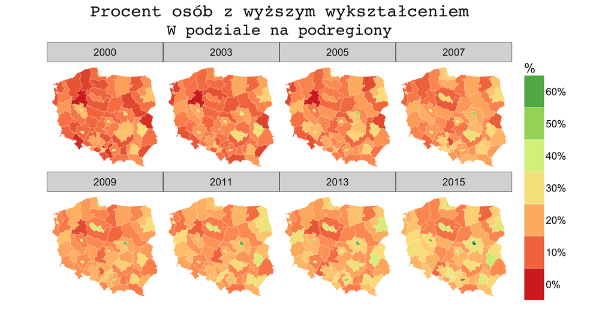

## Co chcemy potrafić zrobić?

- Pomalować wybrany obszar kolorem zależnym od pewnej zmiennej. Ewentualnie dodać etykietkę
- Potrzebujemy wobec tego definicji każdego obszaru…
- … a także połączenia obszaru ze zmienną nas interesującą (np. z GUSu)

## Czym jest mapa lub problemy z kulistością ziemi

- określonym matematycznie obrazem przestrzeni odzwierciedlającym rozmieszczenie obiektów i zjawisk geograficznych w zmniejszeniu (skala) i rzucie prostokątnym (odwzorowanie)
- zbiorem znaków kartograficznych i napisów, służących do prezentacji obiektów i zjawisk geograficznych
- odzwierciedla rzeczywistość w **specyficznie uogólniony sposób** – może być traktowana jako jej model.
- Na podstawie wykładu z Podstaw Kartografii dr. Waldemara Spalleka

## Technikalia

- Dane znajdują się specjalnych plikach. Najczęściej shp lub gjson. Można je wczytać do R za pomocą pakietu **rgdal**
- Skąd wziąc dane?
- CODGiK (województwa, powiaty, gminy)
- Portal Geostatystyczny (jednostki statystyczne)
- Eurostat (NUTS 1,2,3)
- Ludzie dobrej woli :)

```r
require(rgdal) #funkcja readOGR
require(rgeos) #funkcja gSimplify i spTransform
library(ggplot2) #funkcja fortify
```

```r
Wojewodztwa <- readOGR("data/wojewodztwa/", "wojewodztwa",
                                             encoding = "utf8")
#' zapisujemy informacje o województwach, które utracimy przy
#' przeksztłcenia w data.frame
wojewodztwa_nazwy_kody <- data.frame(id = as.character(0:15),
                                     teryt = Wojewodztwa$jpt_kod_je,
                                     woj = Wojewodztwa$jpt_nazwa_,
                                     stringsAsFactors = FALSE)
```

```r
#' zmniejszamy dokładność, dzięki temu mapa będzie się
#' szybciej rysować i zajmie mniej miejsca
wojewodztwa <- gSimplify(Wojewodztwa, tol = 1000, topologyPreserve = TRUE)
#' Jak mówiliśmy wcześniej jest wiele możliwych układów współrzędnych
wojewodztwa <- spTransform(wojewodztwa, CRS("+proj=longlat +datum=WGS84"))
Wojewodztwa <- fortify(wojewodztwa)

#' wyznaczamy centroidy województw (przydatne do etykietek)
centroidy_wojewodztw = data.frame(gCentroid(wojewodztwa, byid = TRUE))
centroidy_wojewodztw$id <- rownames((centroidy_wojewodztw))
```

## Najpierw przetwarzamy dane

```r
load("data/uzywanie_internetu_diagnoza_spoleczna.Rdata")
plotData <- inner_join(Wojewodztwa, internet_podsumowanie,
                                             by = c("id" = "woj_id"))
```

## Wizualizacja

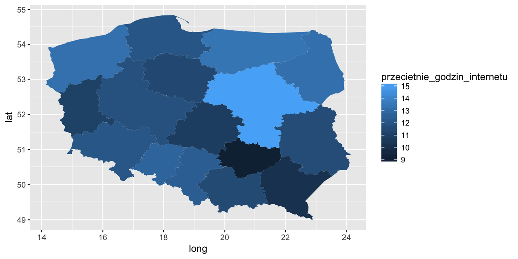

[figure not shown]

```r
ggplot(data = plotData, mapping = aes(x = long, y = lat)) +
  geom_polygon(mapping = aes(group = group, fill = przecietnie_godzin_internetu))
```

## Rysowanie mapy

[figure not shown]

```r
ggplot(data = plotData, mapping = aes(x = long, y = lat)) +
        #rysujemy wielokąty
  geom_polygon(mapping = aes(group = group,
                             fill = przecietnie_godzin_internetu)) +
    #ustawiamy układ współrzędnych
    coord_map() +
        #ustalamy paletę kolorów i skalę
  scale_fill_distiller("h", palette = "YlGn",
                                breaks = pretty_breaks(n = 6),
                                trans = "reverse") +
        #ustawiamy obok siebie wykresy dla poszczególnych lat
  facet_wrap(~wiek, nrow = 2, ncol = 3) +
  guides(fill = guide_legend(reverse = TRUE)) +
    labs(title = "Liczba godzin spędzonych w internecie",
             subtitle = "tygodniowo, w podziale na województwa") +
        #sugerowany styl wyglądu mapy
  theme_map(base_size = 18)
```

## Tips and tricks

- Znalezienie projekcji mapy **proj4string(wczytane.shp)**
- Umieszczenie legendy w ,,wolnym miejscu" **theme(legened.position = c(0.1,0.1))**
- Dodanie etykietek w środku wielokątu **geom_label**
- Dodanie dodatkowego opisu na dole **labs(caption = "bla, bla, bla")**